# GLM and EM algorithm

## 1. GLM

#### 1.1 Binary regression

###### 1.1.1 Example : Beetles data

유독가스에 5시간 노출되었을 때 딱정벌레의 사망률이 가스의 농도에 따라 어떻게 변하는지를 보기 위해 수집된 자료이다. 딱정벌레의 사망여부가 반응변수($y_i$)가 되고 가스농도가 설명변수($x_i$)가 되며, 반응변수가 이진변수이므로 GLM을 적용하는 것이 적절하다.

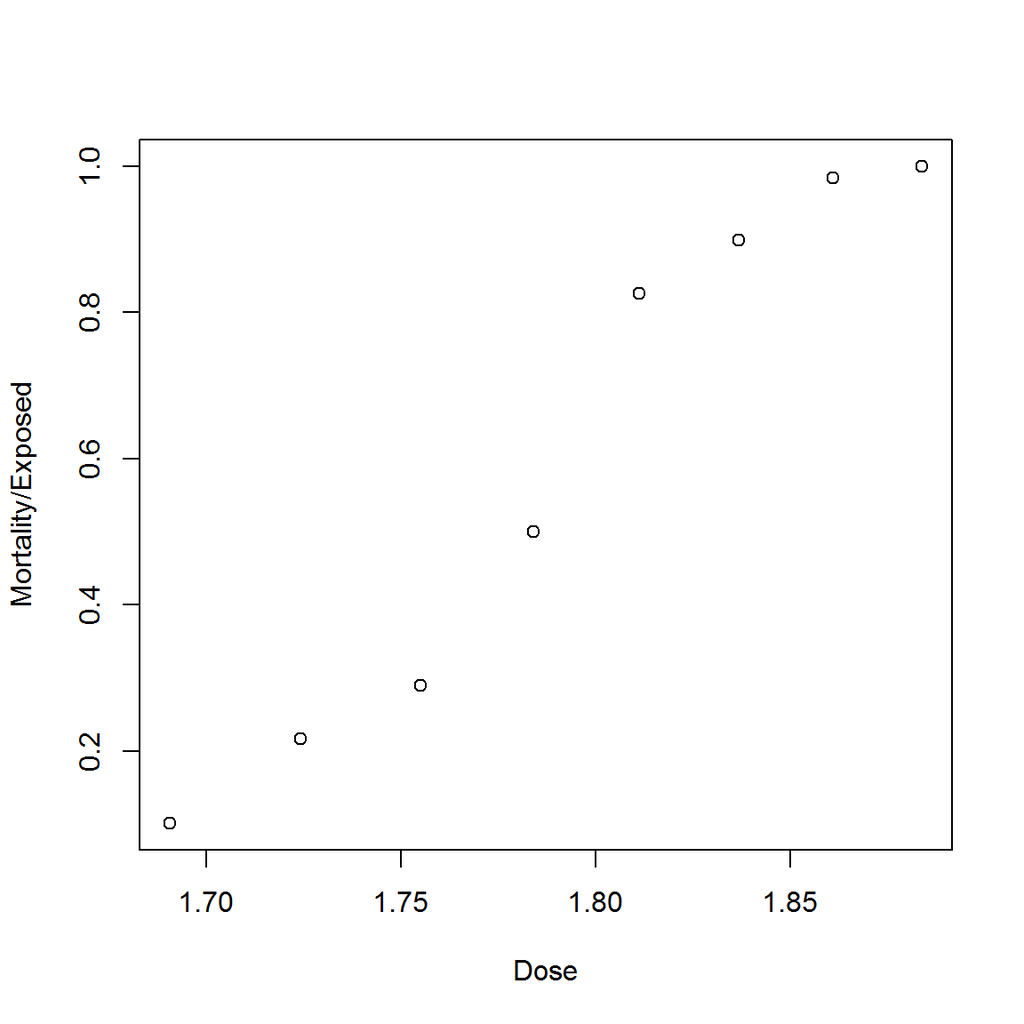

```r
beetle <- read.table("beetles.txt",header=TRUE)
attach(beetle)
plot(Dose,Mortality/Exposed)
```

- Logistic link

```r
logit1 <- glm(cbind(Mortality,Exposed-Mortality)~Dose,family=binomial(link="logit"))
summary(logit1)
```

```
##
## Call:
## glm(formula = cbind(Mortality, Exposed - Mortality) ~ Dose, family = binomial(link = "logit"))
##
## Deviance Residuals:
##     Min       1Q   Median       3Q      Max
## -1.5941  -0.3944   0.8329   1.2592   1.5940
##
## Coefficients:
##             Estimate Std. Error z value Pr(>|z|)
## (Intercept)  -60.717      5.181  -11.72   <2e-16 ***
## Dose          34.270      2.912   11.77   <2e-16 ***
## ---
## Signif. codes:  0 '***' 0.001 '**' 0.01 '*' 0.05 '.' 0.1 ' ' 1
##
## (Dispersion parameter for binomial family taken to be 1)
##
##     Null deviance: 284.202  on 7  degrees of freedom
## Residual deviance:  11.232  on 6  degrees of freedom
## AIC: 41.43
##
## Number of Fisher Scoring iterations: 4
```

적합된 모형은

$\log\frac{p_i}{1-p_i}=-60.72+34.27\cdot x_i,~~p_i=P(Y_i=1)$

- Probit link

```r
probit1 <- glm(cbind(Mortality,Exposed-Mortality)~Dose,family=binomial(link="probit"))
summary(probit1)
```

```
##
## Call:
## glm(formula = cbind(Mortality, Exposed - Mortality) ~ Dose, family = binomial(link = "probit"))
##
## Deviance Residuals:
##     Min       1Q   Median       3Q      Max
## -1.5714  -0.4703   0.7501   1.0632   1.3449
##
## Coefficients:
##             Estimate Std. Error z value Pr(>|z|)
## (Intercept)  -34.935      2.648  -13.19   <2e-16 ***
## Dose          19.728      1.487   13.27   <2e-16 ***
## ---
## Signif. codes:  0 '***' 0.001 '**' 0.01 '*' 0.05 '.' 0.1 ' ' 1
##
## (Dispersion parameter for binomial family taken to be 1)
##
##     Null deviance: 284.20  on 7  degrees of freedom
## Residual deviance:  10.12  on 6  degrees of freedom
## AIC: 40.318
##
## Number of Fisher Scoring iterations: 4
```

적합된 모형은

$\Phi^{-1}(p_i)=-34.94+19.73\cdot x_i,~~\Phi(t)=P(Z\leq t)$

- Complementary log-log link

```r
cll1 <- glm(cbind(Mortality,Exposed-Mortality)~Dose,family=binomial(link="cloglog"))
summary(cll1)
```

```
##
## Call:
## glm(formula = cbind(Mortality, Exposed - Mortality) ~ Dose, family = binomial(link = "cloglog"))
##
## Deviance Residuals:
##      Min        1Q    Median        3Q       Max
## -0.80329  -0.55135   0.03089   0.38315   1.28883
##
## Coefficients:
##             Estimate Std. Error z value Pr(>|z|)
## (Intercept)  -39.572      3.240  -12.21   <2e-16 ***
## Dose          22.041      1.799   12.25   <2e-16 ***
## ---
## Signif. codes:  0 '***' 0.001 '**' 0.01 '*' 0.05 '.' 0.1 ' ' 1
##
## (Dispersion parameter for binomial family taken to be 1)
##
##     Null deviance: 284.2024  on 7  degrees of freedom
## Residual deviance:   3.4464  on 6  degrees of freedom
## AIC: 33.644
##
## Number of Fisher Scoring iterations: 4
```

적합된 모형은

$\log(-\log(1-p_i))=-39.57+22.04\cdot x_i$

1. 세 link에 의한 모형 모두 유의한 모형을 생성하였다.
2. logit link의 경우 추정된 계수값이 다른 두 링크와 약간 다르게 나타났으며, dose에 의한 효과가 가장 크게 평가되었다.
3. 세 경우에 대하여 적합된 회귀함수를 그려보면 다음과 같다.

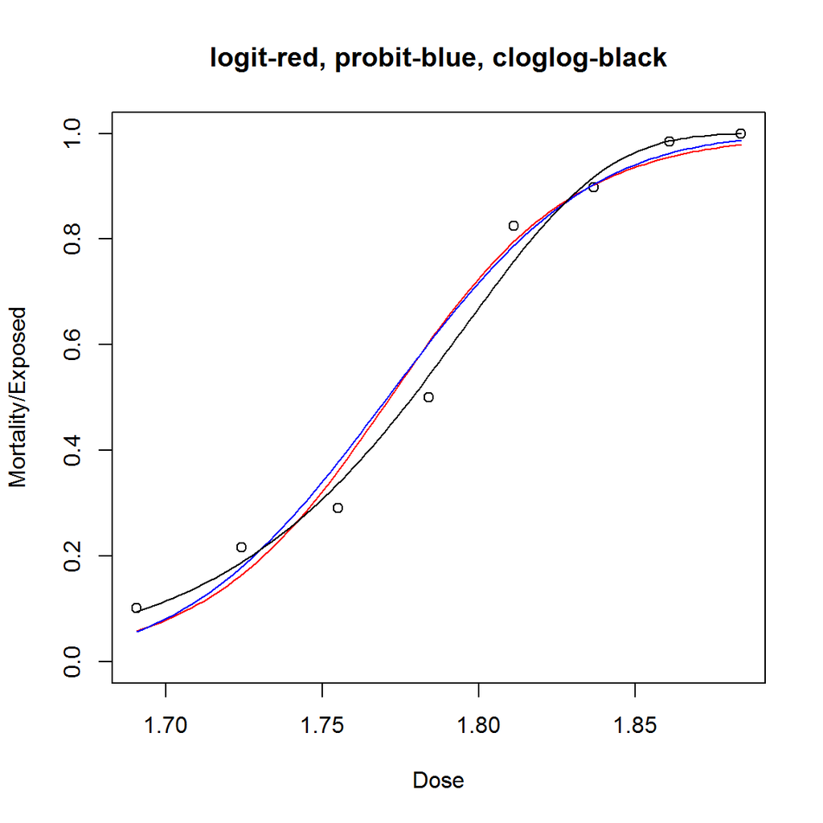

```r
plot(Dose,Mortality/Exposed,main="logit-red, probit-blue, cloglog-black",ylim=c(0,1))
xdose=data.frame(Dose=seq(min(Dose),max(Dose),diff(range(Dose))/100))
lines(xdose$Dose,predict(logit1,xdose,type="response"),col="red")
lines(xdose$Dose,predict(probit1,xdose,type="response"),col="blue")
lines(xdose$Dose,predict(cll1,xdose,type="response"))
```

###### 1.1.2 어떤 link를 쓸 것인가?

1. Deviance

선형회귀모형에서 모형의 적합도를 평가하는 기준으로 잔차제곱합(RSS:Residual sum of squares)을 생각할 수 있다. Deviance는 우도함수에 기초하여 모형을 적합할 때 (즉, GLM과 같은 세팅 하에서) 적용할 수 있도록 RSS를 일반화 및 확장한 개념으로 볼 수 있다. 다음과 같이 정의된다.

$D = -2(\log l(\hat\theta)- \log l(\hat\theta_s)) ,~~\hat\theta : MLE~in~the~model,~\hat\theta_s : MLE~ in~ the~ saturatd~ model.$

cf) 포화모형(saturated model)이란 모든 데이터가 완벽히 적합되는 (perfectly fitted) 모형을 말한다.

이는 모형 간의 로그우도비를 정의한 것과 같다. 즉, deviance가 작은 모형일 수록 적합이 잘 되었다고 할 수 있다. Deviance는 적절한 가정 하에서 점근적으로 카이제곱분포를 따른다는 사실이 알려져 있으며, 이 때 자유도는 제안된 모형과 포화모형간의 모수의 개수와 같다.

만약, 두 개의 nested 구조를 가진 모형($M_1$, $M_2$)이 있다고 하고 $M_1$이 모수 $\theta_1$에 의존하고 $M_2$가 추가적인 모수 $\theta_2\in R^k$를 포함한 $(\theta_1,\theta_2)$에 의존한다고 하자. 그러면, 다음과 같은 가설

$H_0 : \theta_2=0~~~vs~~~H_1:\theta_2\neq 0$

의 검정을 위한 검정통계량은 두 모형의 deviance의 차이 $D = -2(\log l(\hat\theta_1)- \log l(\hat\theta_1,\hat\theta_2))$가 되고 이는 귀무가설 하에서 점근적으로 자유도 $k$인 카이제곱분포를 따른다.

서로 다른 link를 사용한 모형들을 deviance를 이용하여 검정절차를 수행하는 것은 불가능하나, RSS의 확장의 개념으로 이해한다면, 상대적으로 작은 deviance를 주는 모형이 적합도 면에서 우수하다고 볼 수 있을 것이다.

2. 적합하고자 하는 자료(혹은 자료가 생성된 field)의 속성

각 link가 제안된 배경이 다르고, 분야마다 선호하는 link가 있을 수 있다. 따라서, 각 link의 속성을 이해하는 것이 선택에 도움이 될 수 있다.

link들의 제안된 순서는 cloglog(1922) < probit(1933) < logit(1944)로 알려져 있다.

cloglog는 토양이나 물을 1/2씩 희석함에 따라 오염확률이 어떻게 변하는지를 모형화하고자 제안되었다.

$\pi = 1- \exp(-p_0v/2^x),~p_0:최초오염도,~x:희석회수,~v:부피$ $\log(-\log(1-\pi)) = \log v + \log p_0 - x\log 2$

probit은 살충효과가 살충제의 농도에 따라 어떻게 변하는지를 분석하며 제안되었다.

logit은 probit link의 대안으로써 소개되었다. pribit 함수와 매우 유사하지만 (logit의 꼬리가 조금 더 두터움) 해석이나 모형적합시에 여러 장점이 있다고 주장하였다.

현재는 logit link를 기본으로 사용하는 경우가 대부분이나, 일부 경제학자들은 probit을 (z-score의 관점에서 해석 가능) 독성학자들은 logit을 선호하는 것으로 알려져 있다. 또한 cloglog는 skewed data에 적합한 것으로 알려져 있다. 실제로 다른 두 link는 $p=0.5$를 기준으로 대칭이나 cloglog는 비대칭이다.

logit이 가장 대중적인 된 두 가지 이유는 첫째, 정준연결함수(canonical link function)이므로 이론적으로 좋은 성질을 가지고 둘째, 오즈비(odds ratio)를 회귀계수와 연관지어 직접적으로 해석하는 것이 가능하기 때문이다.

- 오즈

$\frac{p_i}{1-p_i}$

- 오즈비 (두 개체 i,j)

$\frac{\frac{p_i}{1-p_i}}{\frac{p_j}{1-p_j}}$

따라서, logistic 모형에서 오즈비는

$\frac{\frac{p_i}{1-p_i}}{\frac{p_j}{1-p_j}}=\exp((x_i-x_j)^\top\theta)$

반면, probit모형에서 오즈비는

$\frac{\frac{p_i}{1-p_i}}{\frac{p_j}{1-p_j}}=\frac{\frac{\Phi(x_i^\top\theta)}{1-\Phi(x_i^\top\theta)}}{\frac{\Phi(x_j^\top\theta)}{1-\Phi(x_j^\top\theta)}}$

위 beetle의 예에서

```r
logit1
```

```
##
## Call:  glm(formula = cbind(Mortality, Exposed - Mortality) ~ Dose, family = binomial(link = "logit"))
##
## Coefficients:
## (Intercept)         Dose
##      -60.72        34.27
##
## Degrees of Freedom: 7 Total (i.e. Null);  6 Residual
## Null Deviance:       284.2
## Residual Deviance: 11.23     AIC: 41.43
```

Dose에 해당하는 추정치가 34.27이므로, Dose 레벨을 0.01 올렸을 때와 이전과의 오즈비는

$\exp(0.3427)=1.4087$

이 된다.

#### 1.2 Log-linear model on contingency tables

###### 1.2.1 Example : Heart disease data

$\begin{array}{c|cc|c} Serun cholesterol & Heart disease(Y) & Heart disease(N) & Total\\\hline <260 & 51 & 992 & 1043\\ >=260 & 41 & 245 &286 \\\hline & 92 & 1237 &1329\\ \end{array}$

각 cell이 포아송분포를 따르고 평균이 $\lambda_{ij},~i,j=1,2$라고 하자. 또한 모두 독립이라고 가정하자. 평균을 다음과 같이 모형화할 수 있다.

$\log\lambda_{ij}=\lambda_0 + \lambda_x X_i + \lambda_y Y_j,~~i,j=1,2.$

여기서 $X_i$, $Y_j$는 각각 분할표의 행과 열변수에 대한 dummy 변수이며, $X_1=Y_1=0$이다.

($\log\lambda_{ij}=\lambda_0 + \alpha_i + \beta_j,~~i,j=1,2,~\alpha_1=\beta_1=0$으로 써도 같은 모형)

```r
cc=c(51,992,41,245)
x=factor(c(0,1,0,1))
y=factor(c(0,0,1,1))
ll=glm(cc~x+y,family=poisson(link="log"))
summary(ll)
```

```
##
## Call:
## glm(formula = cc ~ x + y, family = poisson(link = "log"))
##
## Deviance Residuals:
##      1       2       3       4
## -2.635   0.678   4.158  -1.317
##
## Coefficients:
##             Estimate Std. Error z value Pr(>|z|)
## (Intercept)  4.27946    0.10524   40.66   <2e-16 ***
## x1           2.59866    0.10806   24.05   <2e-16 ***
## y1          -1.29386    0.06675  -19.38   <2e-16 ***
## ---
## Signif. codes:  0 '***' 0.001 '**' 0.01 '*' 0.05 '.' 0.1 ' ' 1
##
## (Dispersion parameter for poisson family taken to be 1)
##
##     Null deviance: 1658.18  on 3  degrees of freedom
## Residual deviance:   26.43  on 1  degrees of freedom
## AIC: 59.836
##
## Number of Fisher Scoring iterations: 4
```

적합된 모형은

$\log \hat\lambda_{ij}=4.28 + 2.60\cdot X_i - 1.29 \cdot Y_i.$

또한, 위 모형에 의한 각 cell에 대한 예측값은 다음과 같으며, 이는 multinomial 모형 하에서 독립성 검정을 위해 얻어진 각 cell의 기대도수와 같음을 알 수 있다.

```r
predict(ll,type="response")
```

```
##         1         2         3         4
##  72.20166 970.79834  19.79834 266.20166
```

```r
tb=matrix(cc,2,2)
colSums(tb)%*%t(rowSums(tb))/sum(tb)
```

```
##          [,1]     [,2]
## [1,] 72.20166 970.7983
## [2,] 19.79834 266.2017
```

```r
chisq.test(tb)
```

```
##
##  Pearson's Chi-squared test with Yates' continuity correction
##
## data:  tb
## X-squared = 29.6331, df = 1, p-value = 5.221e-08
```

즉, multinommial 모형 하에서와 poisson 모형 하에서의 예측치는 동일하게 주어진다. 만약 독립성이 성립한다면,

$P(X=i,Y=j)=\pi_{ij}=\pi_{i\cdot}\pi_{\cdot j}=P(X=i)P(Y=j).$

위 식에 로그를 취하면,

$\log\pi_{ij} = \log\pi_{i \cdot}+\log\pi_{\cdot j}$

꼴이 되어, log-linear 모형과 동일한 꼴이 된다. 즉, 분할표에서 교호작용(interaction-effect)을 고려하지 않은 log-linear 모형은 행과 열 변수 사이에 독립성을 가정한 것이다. 교호작용을 고려한 모형은 포화모형이 된다.

```r
lls=glm(cc~x*y,family=poisson(link="log"))
summary(lls)
```

```
##
## Call:
## glm(formula = cc ~ x * y, family = poisson(link = "log"))
##
## Deviance Residuals:
## [1]  0  0  0  0
##
## Coefficients:
##             Estimate Std. Error z value Pr(>|z|)
## (Intercept)   3.9318     0.1400  28.079  < 2e-16 ***
## x1            2.9679     0.1436  20.670  < 2e-16 ***
## y1           -0.2183     0.2098  -1.041    0.298
## x1:y1        -1.1802     0.2216  -5.327 9.99e-08 ***
## ---
## Signif. codes:  0 '***' 0.001 '**' 0.01 '*' 0.05 '.' 0.1 ' ' 1
##
## (Dispersion parameter for poisson family taken to be 1)
##
##     Null deviance:  1.6582e+03  on 3  degrees of freedom
## Residual deviance: -3.7081e-14  on 0  degrees of freedom
## AIC: 35.406
##
## Number of Fisher Scoring iterations: 2
```

즉, 분할표에서 독립성을 검정하고자 할 때에는 교호작용을 고려하지 않은 모형과 고려한 모형을 적합하여 deviance의 차이를 가지고 검정할 수 있다.

$\log\lambda_{ij}=\lambda_0 + \lambda_x X_i + \lambda_y Y_j + \lambda_{xy} X_iY_j,~~i,j=1,2.$

$H_0 : \lambda_{xy}=0 (독립)~~~vs~~~H_1:not~H_0.$

```r
anova(ll,lls)
```

```
## Analysis of Deviance Table
##
## Model 1: cc ~ x + y
## Model 2: cc ~ x * y
##   Resid. Df Resid. Dev Df Deviance
## 1         1      26.43
## 2         0       0.00  1    26.43
```

```r
lls=glm(cc~x*y,family=poisson(link="log"))
diff.d=ll$deviance-lls$deviance
1-pchisq(diff.d,1)
```

```
## [1] 2.732848e-07
```

```r
library(epicalc)
lrtest(ll,lls)
```

```
## Likelihood ratio test for MLE method
## Chi-squared 1 d.f. =  26.42985 , P value =  2.732848e-07
```

###### 1.2.2 3-way contingency tables

Factor가 셋인 경우에는 가능한 모형이 복잡해진다. 세 변수가 모두 서로 독립일 수도 있고, 일부끼리만 독립일 수도 있으며 모두 연관되어 있을 수도 있다.

모두 독립이면

$\log\lambda_{ijk}=\lambda_0+\alpha_i+\beta_j+\gamma_k.$

와 같은 형태의 모형이 될 것이고, 모두 연관되어 있으면

$\log\lambda_{ijk}=\lambda_0+\alpha_i+\beta_j+\gamma_k+\alpha_{ij}+\beta_{jk}+\gamma_{ki}+\eta_{ijk}.$

와 같이 된다. 물론 두 형태의 중간형태로써

$\log\lambda_{ijk}=\lambda_0+\alpha_i+\beta_j+\gamma_k+\alpha_{ij}+\beta_{jk}.$

와 같은 모형도 생각할 수 있다.

- 대학 입학생 수 자료

```r
admit<-as.data.frame(UCBAdmissions)
admit
```

```
##       Admit Gender Dept Freq
## 1  Admitted   Male    A  512
## 2  Rejected   Male    A  313
## 3  Admitted Female    A   89
## 4  Rejected Female    A   19
## 5  Admitted   Male    B  353
## 6  Rejected   Male    B  207
## 7  Admitted Female    B   17
## 8  Rejected Female    B    8
## 9  Admitted   Male    C  120
## 10 Rejected   Male    C  205
## 11 Admitted Female    C  202
## 12 Rejected Female    C  391
## 13 Admitted   Male    D  138
## 14 Rejected   Male    D  279
## 15 Admitted Female    D  131
## 16 Rejected Female    D  244
## 17 Admitted   Male    E   53
## 18 Rejected   Male    E  138
## 19 Admitted Female    E   94
## 20 Rejected Female    E  299
## 21 Admitted   Male    F   22
## 22 Rejected   Male    F  351
## 23 Admitted Female    F   24
## 24 Rejected Female    F  317
```

```r
attach(admit)
ms=glm(Freq~Gender*Dept*Admit,family=poisson(link="log"))
ma=glm(Freq~Gender+Dept+Admit,family=poisson(link="log"))
lrtest(ms,ma)
```

```
## Likelihood ratio test for MLE method
## Chi-squared 16 d.f. =  2097.671 , P value =  0
```

```r
ma2=glm(Freq~Dept+Gender:Admit,family=poisson(link="log"))
lrtest(ma2,ma)
```

```
## Likelihood ratio test for MLE method
## Chi-squared 1 d.f. =  93.44941 , P value =  4.167175e-22
```

#### 1.2 Other issues for modeling count data

count data는 포아송분포를 이용하여 모형화하는 것이 가장 일반적이다. 하지만, 어떠한 경우에는 이것이 적합하지 않을 수도 있다.

1. Overdispersion

포아송분포의 독특한 성질은 평균과 분산이 같다는 것이다. 하지만, 어떠한 경우 (독립성이 깨지거나 다른 설명변수를 고려하지 않는 등의 이유로 발생할 수 있음)에는 분산이 평균보다 크게 측정되기도 하는데 이럴 때는 포아송 모형을 그대로 쓰기에는 무리가 있을 수 있다. 보통 Deviance residual 등을 이용하여 detect 할 수 있는데, 대안으로는 보통 다음 두 가지를 고려한다.

- overdispersion parameter를 도입

$E(Y)=Var(Y)=\lambda$가 성립하지 않으므로 $Var(Y)=\phi \lambda$와 같이 새로운 모수 $\phi$를 도입하는 방법이다. 기본적인 평균에 대한 모형과 우도함수에 근거한 추정방식은 거의 동일하며 R에서 glm을 이용하여 쉽게 적합이 가능하다.

적합된 모형의 추정치 및 평균에 대한 예측치는 $\phi$를 도입하지 않았을 때와 동일하다. (why?) 하지만, 추정치의 standard error는 달라지게 된다.

- 음이항분포(Negative binomial) 이용

음이항분포도 0이상의 정수를 취하는 분포이므로 count data의 모형화에 적합하다. 또한, Poisson 분포와는 달리 분산이 평균과 다르므로 (더 크므로) overdispersion 문제를 해결할 수 있다.

2. Excess zeros

count data에서 0는 발생한 사건이 1개도 없음을 의미한다. 이것은 실제 poisson 분포에서 관측된 결과일 수도 있지만 어떤 경우에는 완전히 다른 process로부터 생성된 것일수도 있어 이를 구분하는 것이 필요하다.

예를 들어, 어떤 공원에서 잡히는 물고기의 수를 함께 온 사람이 수, 아이가 함께 있는 지의 여부, 얼마나 오래 머물렀는지 등에 의해 모형화 한다고 가정하자. 만약, 어떤 사람이 물고기를 한 마리도 잡지 못했다고 답했다면 이는 (1) 실제로 잡으려고 시도했으나 잡지 못했거나 (2) 아예 낚시를 하지 않았거나 둘 중 하나의 경우일 것이다. (1)이라면, poisson에서 0이 관측된 것으로 볼 수 있으나 (2)는 그렇게 생각할 수 없다.

이 경우 모형은

$\lambda_i = \pi_i + (1-\pi_i)\exp(x_i^\top\theta),~\pi:포아송분포로~관측되지~않을~확률$

와 같이 표현할 수 있으며 보통 $\pi$는 또 다른 변수에 의해 모형화 하게 된다.

(R에서는 zeroinfl 함수에 의해 적합할 수 있음.)

#### 1.3 Exercise

1. Titanic data
2. Award data

## 2. EM (Expectatin and Maximization) algorithm

EM은 MLE의 계산을 위한 알고리즘 중 하나로, missing data가 존재할 때 이를 처리 또는 해결하기 위해 고안되었다. E step 과 M step을 돌아가면 반복하게 되며 E step은 missing data를 채우는 과정으로 이해할 수 있다. 이후, E step에 의해 얻어진 함수(우도함수를 대체하는 surrogate function)를 maximize 함으로써 모수의 추정치를 업데이트하게 되며 이를 M step이라 한다. 보통 surrogate function은 우도함수에 비해 간단한 형태로 주어지게 되어 maximize가 상대적으로 쉽다.

EM 알고리즘의 가장 큰 장점은 매 업데이트마다 우도함수의 값이 증가한다는 점이다. 즉, 알고리즘이 매우 안정적이다.

반면, EM의 단점 중 하나는 수렴속도가 느릴 수 있다는 것인데 특히 MLE(maximum point) 근방에서 수렴속도가 매우 느려지기도 한다. 이는, missing data의 존재 때문인데 missing된 양이 얼마나 큰가에 좌우되는 것으로 알려져 있다.

만약 우도함수가 concave가 아니고 local maximum이 존재하는 경우에는 EM 알고리즘에 의한 추정치가 global MLE가 된다는 보장은 없다. 이는 초기치에 의존할 것이다.

#### 2.1 EM 알고리즘의 일반적 정의

$X$를 (unobserved) complete data라 하고 pdf가 $f(x|\theta)$라 하자. 반면, $Y$를 (observed) incomplete data라 하자. 즉, $t(X)=Y$를 만족하는 어떤 함수 $t$가 존재한다고 생각할 수 있다.

cf) 간단한 예로 $X=(Y,Z)$이고 $Y$는 관측되지만 $Z$가 missing인 경우를 생각하면, $t$는 projection 함수이다.

EM 알고리즘은 다음과 같이 두 step으로 구성된다.

E - step

$\mbox{compute } Q(\theta|\theta_n) = E[\log f(X|\theta) |Y=y,\theta_n]$

M - step

$\mbox{mazimize } Q(\theta|\theta_n)~w.r.t.~\theta$

여기서 $Q$를 surrogate function이라 한다. $y$는 실제 관측된 observed data이며, $\theta_n$이 현재 모수 추정치이다.

만약 $g(y|\theta)$가 observed data에 대한 우도함수이면 항상

$\log g(y|\theta_{n+1}) \geq \log g(y|\theta_n)$

이 성립한다. 이는 젠센부등식(Jensen’s inequality)로부터 유도되는 성질이다. (생략)

#### 2.2 Examples

###### 2.2.1 Alle frequency estimation

이전 예시에서는 실제 나타난 형질 $A,B,AB,O$의 관측도수 $Y=(n_A,n_B,n_O,n_{AB})$가 다항분포를 따른다는 사실을 이용하여 모수의 추정치를 구했다. 이번에는 유전자형 $A/A,A/O,B/B,B/O,O,AB$이 다항분포를 따른다는 사실을 이용하여 보자. 각 유전자형에 대한 도수를 $X=(n_{A/A},n_{A/O},n_{B/B},n_{B/O},n_{O},n_{AB})$라 하면,

$x\sim Multi(n,p),~p=(p_A^2,2p_Ap_O,p_B^2,2p_Bp_O,p_O^2,2p_Ap_B)$

즉, complete data에 대한 우도함수는

$\log f(X|\theta)=n_{A/A}\log p_A^2 + n_{A/O}\log 2p_Ap_O + n_{B/B}\log p_B^2 + n_{B/O}\log 2p_Bp_O + n_{AB}\log 2p_Ap_B + n_O \log p_O^2$

여기서, $n_{A/A},n_{A/O},n_{B/B},n_{B/O}$는 직접 관측되지 않는다. 즉, missing이 발생한 것으로 이해할 수 있다. E step 적용을 위해 위 함수에 기대값을 취해 보자. 현재 모수에 대한 추정치를 $p_m$이라 하면,

$E(n_{AB}|Y,p_m) = n_{AB}$ $E(n_{O}|Y,p_m) = n_{O}$

임은 명백하다. (위 두 도수에는 missing이 발생하지 않았음)

$E(n_{A/A}|Y,p_m) = n_A \frac{p_{mA}^2}{p_{mA}^2+2p_{mA}p_{mO}}\equiv n_{mA/A}$ $E(n_{A/O}|Y,p_m) = n_A \frac{2p_{mA}p_{mO}}{p_{mA}^2+2p_{mA}p_{mO}}\equiv n_{mA/O}$ $E(n_{B/B}|Y,p_m) = n_B \frac{p_{mB}^2}{p_{mB}^2+2p_{mB}p_{mO}}\equiv n_{mB/B}$ $E(n_{B/O}|Y,p_m) = n_B \frac{2p_{mB}p_{mO}}{p_{mB}^2+2p_{mB}p_{mO}}\equiv n_{mB/O}$

위 조건부 기댓값들을 complete data에 대한 우도함수에 plug-in 시킨 후에 $p$에 대하여 mazimize하면 다음과 같은 updating equation을 얻는다.

$p_{m+1,A}=\frac{2n_{mA/A}+n_{mA/O}+n_{AB}}{2n}$ $p_{m+1,B}=\frac{2n_{mB/B}+n_{mB/O}+n_{AB}}{2n}$ $p_{m+1,O}=\frac{n_{mA/O}+n_{mB/O}+2n_{O}}{2n}$

cf) M step에서는 Lagrangian multiplier를 이용해야 할 수도 있음.

초기치를 $p_{oA}=0.3,p_{oB}=0.2,p_{oO}=0.5$ 로 두고 EM 알고리즘을 실행해보자.

```r
newtheta<-theta<-c(0.3,0.2,0.5)
nAA<-function(y,theta){y[1]*(theta[1]^2/(theta[1]^2+2*theta[1]*theta[3]))}
nAO<-function(y,theta){y[1]*(2*theta[1]*theta[3]/(theta[1]^2+2*theta[1]*theta[3]))}
nBB<-function(y,theta){y[2]*(theta[2]^2/(theta[2]^2+2*theta[2]*theta[3]))}
nBO<-function(y,theta){y[2]*(2*theta[2]*theta[3]/(theta[2]^2+2*theta[2]*theta[3]))}
tol <- 10^{-8}
t <- c(186,38,284,13)
for (i in 1:100)
  {
  newtheta[1] <- (2*nAA(t,theta)+nAO(t,theta)+t[4])/(2*sum(t))
  newtheta[2] <- (2*nBB(t,theta)+nBO(t,theta)+t[4])/(2*sum(t))
  newtheta[3] <- (nAO(t,theta)+nBO(t,theta)+2*t[3])/(2*sum(t))
  err <- max(abs(newtheta-theta))
  print(c(i,theta))
  if (err<tol) break
  theta<-newtheta
  }
```

```
## [1] 1.0 0.3 0.2 0.5
## [1] 2.00000000 0.23217186 0.05502239 0.71280575
## [1] 3.00000000 0.21597814 0.05029955 0.73372231
## [1] 4.00000000 0.21388028 0.05015293 0.73596679
## [1] 5.00000000 0.21362566 0.05014597 0.73622837
## [1] 6.0000000 0.2135951 0.0501454 0.7362595
## [1] 7.00000000 0.21359144 0.05014534 0.73626323
## [1] 8.00000000 0.21359100 0.05014533 0.73626367
## [1] 9.00000000 0.21359095 0.05014533 0.73626372
```

```r
theta
```

```
## [1] 0.21359095 0.05014533 0.73626372
```

이전 챕터에서 얻었던 것과 같은 추정치를 얻는다.

###### 2.2.2 Gaussian mixture (two components)

데이터가 서로 이질적인 여러 집단으로부터 동시에 수집된 경우 mixture 모형을 이용할 수 있다. 예를 들어, paperback형태의 책의 가격은 $N(10,1)$을 따르고 hard cover형태의 책은 $N(17,1.5)$의 가격분포를 가진다고 할 때, 랜덤하게 선택된 어떤 책의 분포는 어떻게 될 것인가?

$f(x)=\pi*N(10,1)+(1-\pi)*N(17,1.5^2)$

의 분포 함수를 가질 것이다. 여기서 $\pi$는 mixing proportion이다.

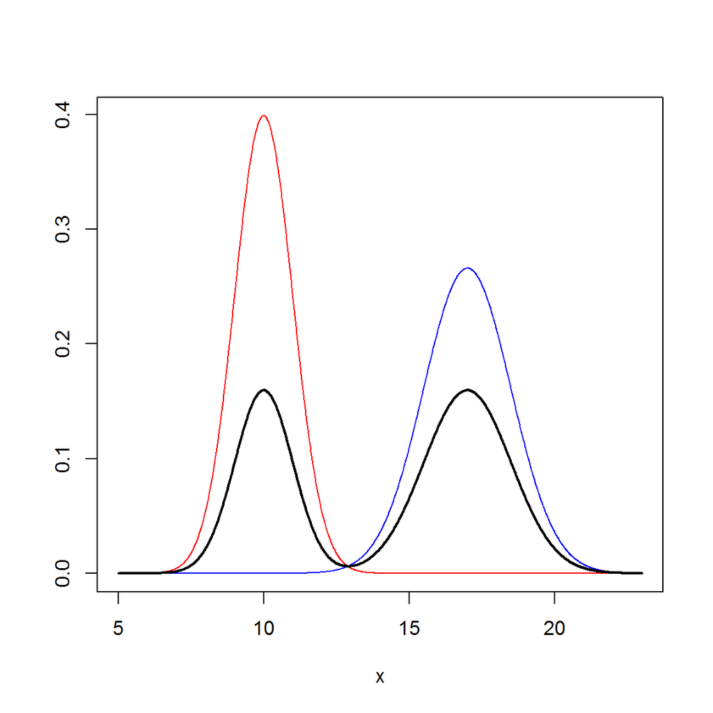

```r
x=seq(5,23,0.01)
pi=0.4
plot(x,dnorm(x,10,1),col="red",type="l",ylab="")
lines(x,dnorm(x,17,(1.5)),col="blue")
lines(x,pi*dnorm(x,10,1)+(1-pi)*dnorm(x,17,(1.5)),lwd=2)
```

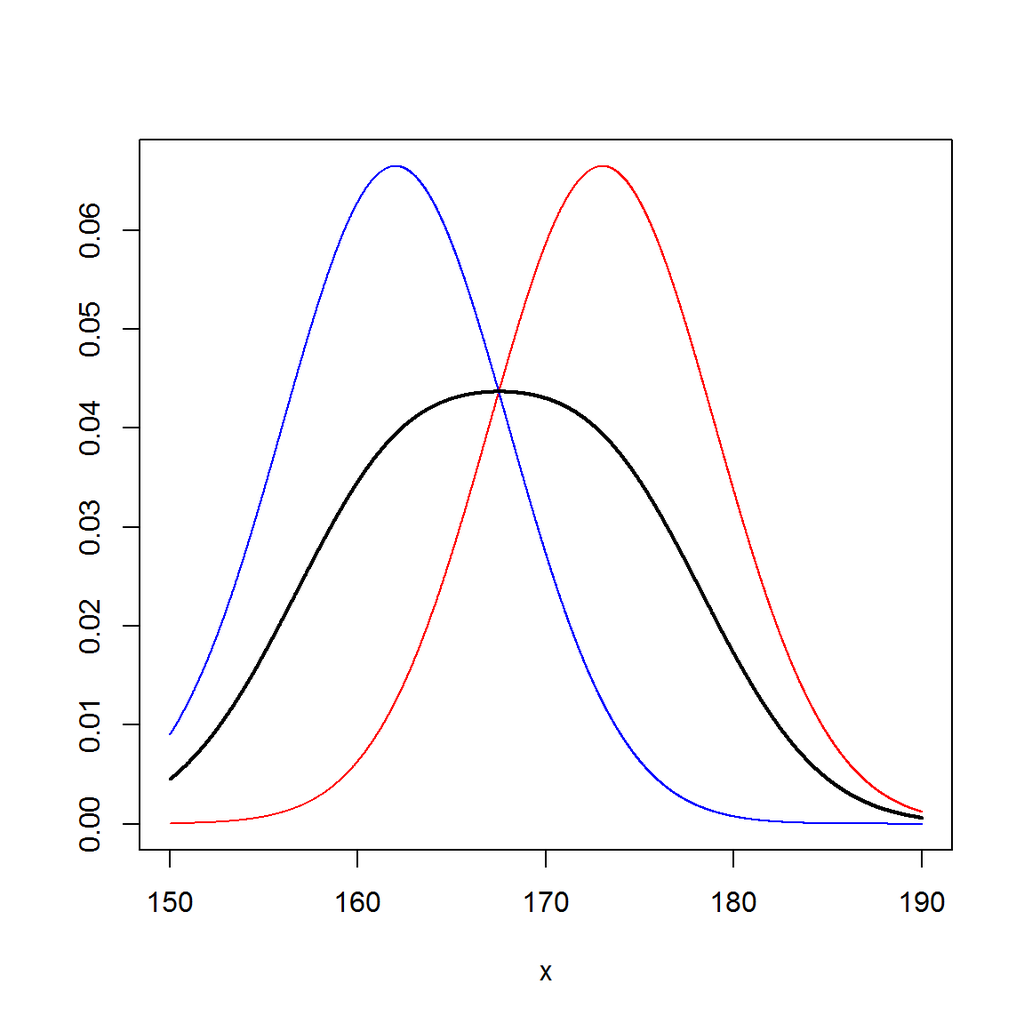

```r
x=seq(150,190,0.01)
pi=0.5
plot(x,dnorm(x,173,6),col="red",type="l",ylab="")
lines(x,dnorm(x,162,6),col="blue")
lines(x,pi*dnorm(x,173,6)+(1-pi)*dnorm(x,162,6),lwd=2)
```

첫 번째 예는 binomdal density를 가지므로 명백히 정규분포가 아니다. 두 번째 예는 unimodal 이지만 이 또한 정규분포로 볼 수 없다.

두 그룹의 결합으로 구성된 Gaussian mixture 모형을 고려해 보자. 일반적으로 label(어떤 드룹에 속하는지)은 알려져 있지 않은 상태로 관측된다. 즉, 우리가 $y_i$를 관측할 뿐 이것이 어떠한 그룹에서 나온 것인지는 알 수 없다. 따라서 label을 나타내는 latent variable $\Delta_i$가 missing 된 것으로 생각할 수 있다.

$(y_i,\Delta_i):\mbox{complete data,}~\mbox{but we observe only} y_i.$

complete data 에 대한 우도함수는

$\log f(Y,\Delta|\theta)=\sum_{i=1}^n \{\Delta_i\log\phi_{\theta_1}(Y_i)+(1-\Delta_i)\log\phi_{\theta_2}(Y_i) +\Delta_i\log\pi+(1-\Delta_i)\log(1-\pi)\}$

where $\theta=(\theta_1,\theta_2,\pi),~\theta_j=(\mu_j,\sigma_j^2),~j=1,2,~\phi_{\theta_j}(\cdot):pdf~of~N(\theta_j,\sigma_j^2)$

- E step

$E(\Delta_i|Y,\theta_m)$을 계산하는 것으로 충분하다.

$E(\Delta_i|Y,\theta_m)=P(\Delta_i=1|Y,\theta_m)=\frac{\pi_m \phi_{\theta_{m1}}(Y_i)}{ \pi_m \phi_{\theta_{m1}}(Y_i)+(1-\pi_m) \phi_{\theta_{m2}}(Y_i)}\overset{let}{\equiv}\hat\Delta_i$

- M step

complete 우도함수에서 $\Delta_i$를 $\hat\Delta_i$으로 대체한 후 surrogate function을 maximize하면,

$\hat\mu_1=\frac{\sum_{i=1}^n\hat\Delta_i Y_i}{\sum_{i=1}^n\hat\Delta_i},~\hat\sigma_1^2=\frac{\sum_{i=1}^n\hat\Delta_i (Y_i-\hat\mu_1)^2}{\sum_{i=1}^n\hat\Delta_i}$ $\hat\mu_2=\frac{\sum_{i=1}^n(1-\hat\Delta_i) Y_i}{\sum_{i=1}^n(1-\hat\Delta_i)},~\hat\sigma_2^2=\frac{\sum_{i=1}^n(1-\hat\Delta_i) (Y_i-\hat\mu_2)^2}{\sum_{i=1}^n(1-\hat\Delta_i)}$ $\hat\pi=\frac{\sum_{i=1}^n \hat\Delta_i}{n}$

- paperback vs hardcover

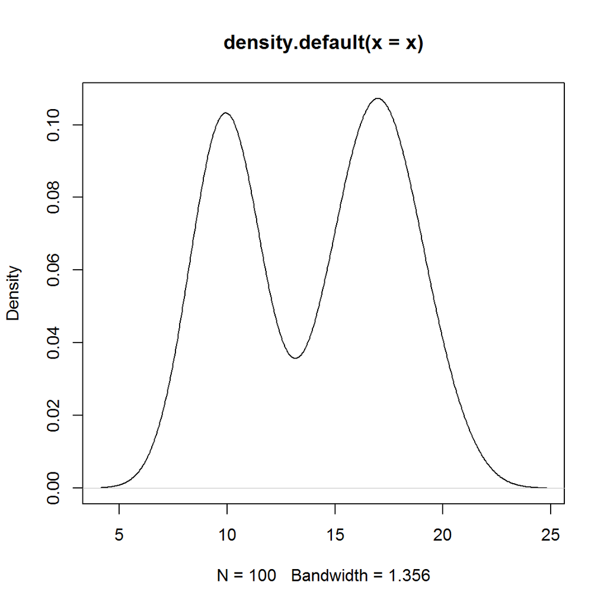

```r
set.seed(1)
n=100
p=0.4
u=rbinom(n,1,p)
x1=rnorm(n,10,1)
x2=rnorm(n,17,1.5)
x=u*x1+(1-u)*x2
plot(density(x))
```

```r
mu1=mean(x)-sd(x)
mu2=mean(x)+sd(x)
s1=s2=var(x)
pi=0.5
for (i in 1:100)
  {
  hatdelta=(pi*dnorm(x,mu1,sqrt(s1)))/(pi*dnorm(x,mu1,sqrt(s1))+(1-pi)*dnorm(x,mu2,sqrt(s2)))
  newmu1=sum(hatdelta*x)/sum(hatdelta)
  news1=sum(hatdelta*(x-newmu1)^2)/sum(hatdelta)
  newmu2=sum((1-hatdelta)*x)/sum((1-hatdelta))
  news2=sum((1-hatdelta)*(x-newmu2)^2)/sum((1-hatdelta))
  newpi=sum(hatdelta)/n
  if (max(abs(mu1-newmu1),abs(mu2-newmu2),abs(s1-news1),abs(s2-news2),abs(pi-newpi))<10E-5) break
  mu1=newmu1
  mu2=newmu2
  s1=news1
  s2=news2
  pi=newpi
  print(c(i,mu1,mu2,s1,s2,pi))
  }
```

```
## [1]  1.0000000 11.3198903 16.6230842  7.8850605  6.4270051  0.4919596
## [1]  2.0000000 10.8920063 16.9800861  5.7985492  4.0724764  0.4871748
## [1]  3.0000000 10.4641242 17.1835347  3.3458639  2.5436756  0.4716794
## [1]  4.0000000 10.1537384 17.1546133  1.6848607  2.3469745  0.4485848
## [1]  5.0000000  9.9977946 17.0857743  1.0081397  2.4703755  0.4333601
## [1]  6.0000000  9.9645631 17.0593763  0.8967848  2.5519666  0.4292219
## [1]  7.0000000  9.9602793 17.0530596  0.8872654  2.5788579  0.4284544
## [1]  8.0000000  9.9594877 17.0516938  0.8857893  2.5849755  0.4282965
## [1]  9.0000000  9.9593238 17.0514048  0.8854915  2.5862787  0.4282633
## [1] 10.0000000  9.9592892 17.0513436  0.8854289  2.5865548  0.4282562
```

```r
library(mclust)
M1=Mclust(x,G=2)
M1$parameters
```

```
## $pro
## [1] 0.4283392 0.5716608
##
## $mean
##        1        2
##  9.95970 17.05207
##
## $variance
## $variance$modelName
## [1] "V"
##
## $variance$d
## [1] 1
##
## $variance$G
## [1] 2
##
## $variance$sigmasq
## [1] 0.8861783 2.5833051
##
## $variance$scale
## [1] 0.8861783 2.5833051
##
##
## $Vinv
## NULL
```

```r
M1$z[,1]>0.5
```

```
##   [1] FALSE FALSE FALSE  TRUE FALSE  TRUE  TRUE  TRUE  TRUE FALSE FALSE
##  [12] FALSE  TRUE FALSE  TRUE FALSE  TRUE  TRUE FALSE  TRUE  TRUE FALSE
##  [23]  TRUE FALSE FALSE FALSE FALSE FALSE  TRUE FALSE FALSE FALSE FALSE
##  [34] FALSE  TRUE  TRUE  TRUE FALSE  TRUE FALSE  TRUE  TRUE  TRUE FALSE
##  [45] FALSE  TRUE FALSE FALSE  TRUE  TRUE FALSE  TRUE FALSE FALSE FALSE
##  [56] FALSE FALSE FALSE  TRUE FALSE  TRUE FALSE FALSE FALSE  TRUE FALSE
##  [67] FALSE  TRUE FALSE  TRUE FALSE  TRUE FALSE FALSE FALSE  TRUE  TRUE
##  [78] FALSE  TRUE  TRUE FALSE  TRUE FALSE FALSE  TRUE FALSE  TRUE FALSE
##  [89] FALSE FALSE FALSE FALSE  TRUE  TRUE  TRUE  TRUE FALSE FALSE  TRUE
## [100]  TRUE
```

```r
library(mixtools)
em1=normalmixEM(x,k=2)
```

```
## number of iterations= 18
```

```r
em1$lambda
```

```
## [1] 0.4282543 0.5717457
```

```r
em1$mu
```

```
## [1]  9.959279 17.051326
```

```r
em1$sigma
```

```
## [1] 0.9409629 1.6083012
```

- men vs women in height

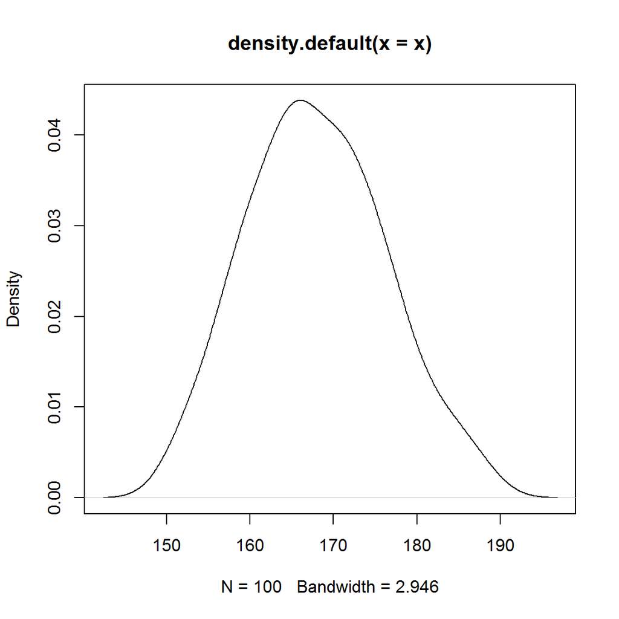

```r
set.seed(1)
n=100
p=0.5
u=rbinom(n,1,p)
x1=rnorm(n,162,6)
x2=rnorm(n,173,6)
x=u*x1+(1-u)*x2
plot(density(x))
```

```r
mu1=mean(x)-sd(x)
mu2=mean(x)+sd(x)
s1=s2=var(x)
pi=0.5
newmu1=newmu2=news1=news2=newpi=ll=c()
for (i in 1:5000)
  {
  hatdelta=(pi*dnorm(x,mu1,sqrt(s1)))/(pi*dnorm(x,mu1,sqrt(s1))+(1-pi)*dnorm(x,mu2,sqrt(s2)))
  newmu1[i]=sum(hatdelta*x)/sum(hatdelta)
  news1[i]=sum(hatdelta*(x-newmu1[i])^2)/sum(hatdelta)
  newmu2[i]=sum((1-hatdelta)*x)/sum((1-hatdelta))
  news2[i]=sum((1-hatdelta)*(x-newmu2[i])^2)/sum((1-hatdelta))
  newpi[i]=sum(hatdelta)/n
  ll[i]=sum(log(newpi[i]*dnorm(x,newmu1[i],sqrt(news1[i]))+(1-newpi[i])*dnorm(x,newmu2[i],sqrt(news2[i]))))
  if (max(abs(mu1-newmu1[i]),abs(mu2-newmu2[i]),abs(s1-news1[i]),abs(s2-news2[i]),abs(pi-newpi[i]))<10E-5) break
  mu1=newmu1[i]
  mu2=newmu2[i]
  s1=news1[i]
  s2=news2[i]
  pi=newpi[i]
  #print(c(i,mu1,mu2,s1,s2,pi))
  }
c(mu1,mu2,s1,s2,pi)
```

```
## [1] 160.9698655 171.2053617  25.4660741  52.9132570   0.3187499
```

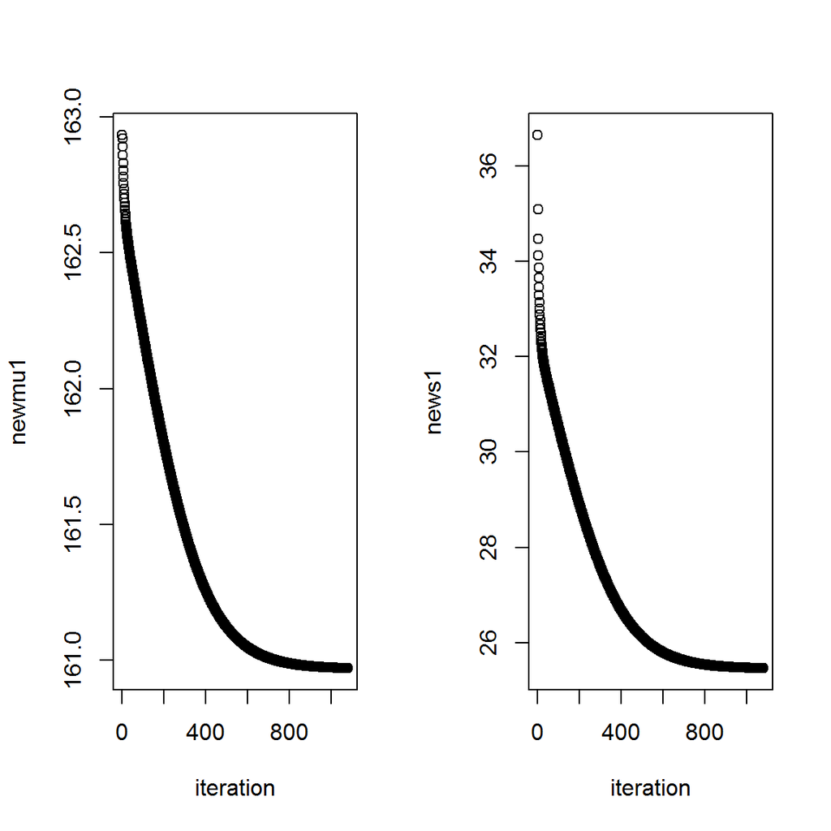

```r
par(mfrow=c(1,2))
plot(newmu1,xlab="iteration")
plot(news1,xlab="iteration")
```

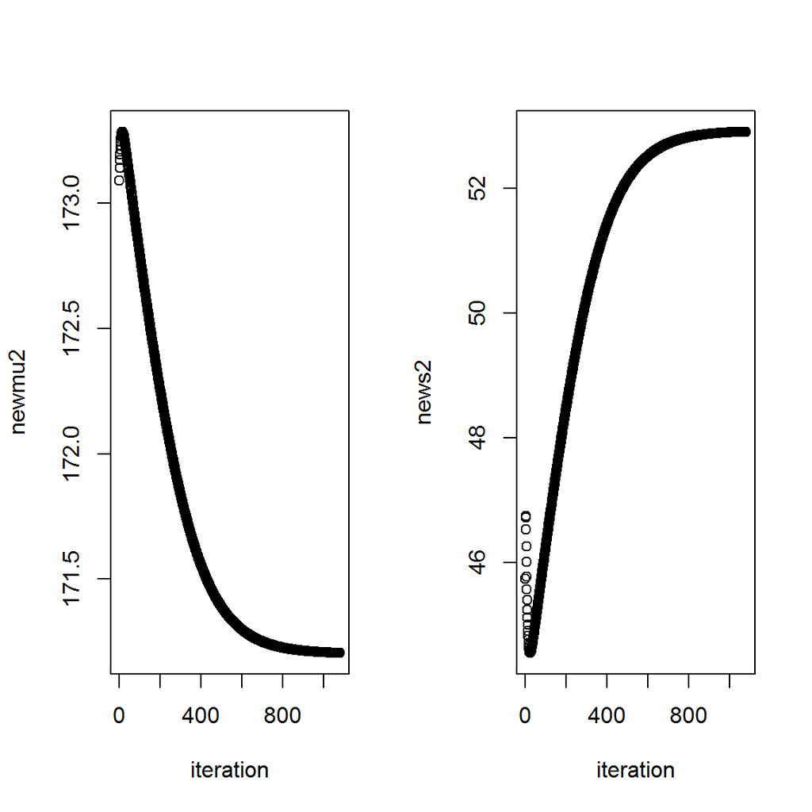

```r
plot(newmu2,xlab="iteration")
plot(news2,xlab="iteration")
```

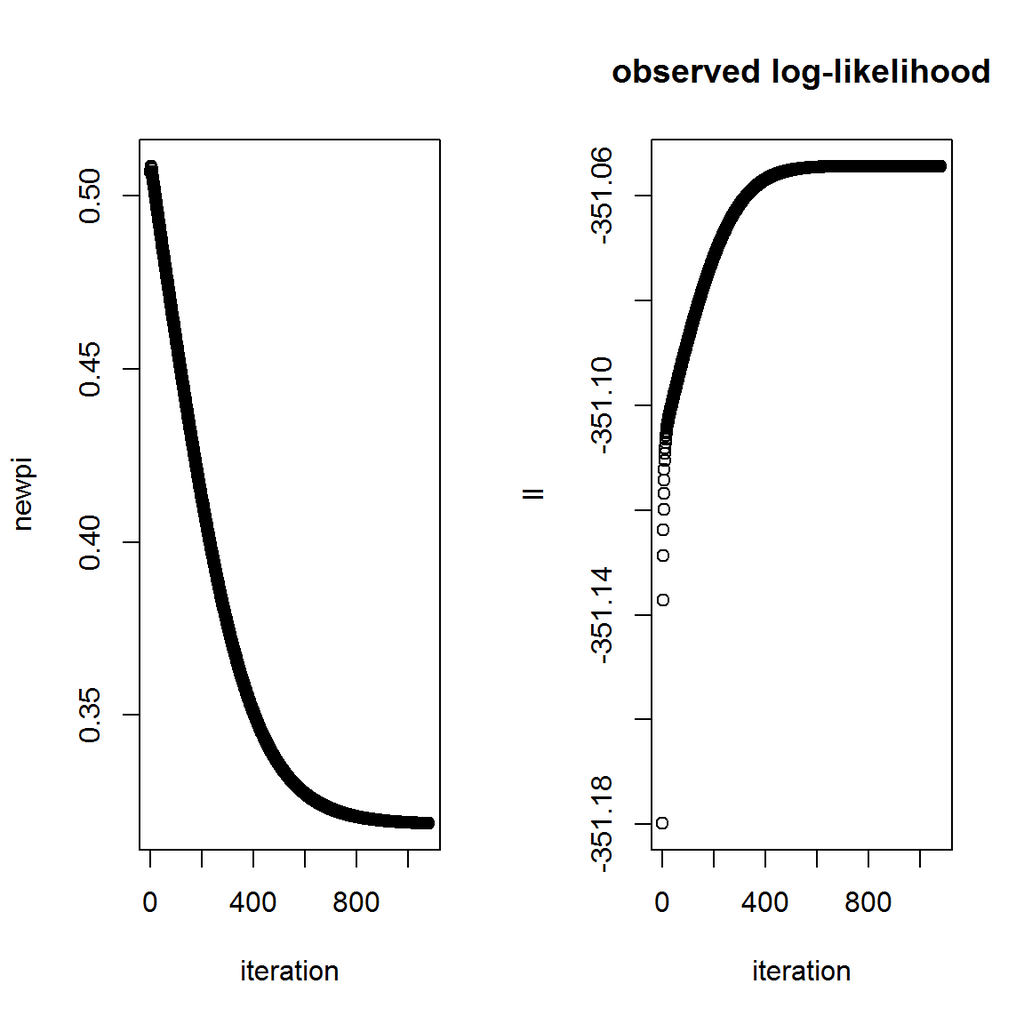

```r
plot(newpi,xlab="iteration")
plot(1:i,ll,main="observed log-likelihood",xlab="iteration")
```

```r
library(mclust)
M2=Mclust(x,G=2)
M2$parameters
```

```
## $pro
## [1] 0.6001458 0.3998542
##
## $mean
##        1        2
## 163.4470 174.6906
##
## $variance
## $variance$modelName
## [1] "E"
##
## $variance$d
## [1] 1
##
## $variance$G
## [1] 2
##
## $variance$sigmasq
## [1] 36.57722
##
##
## $Vinv
## NULL
```

```r
M2$z[,1]>0.5
```

```
##   [1] FALSE FALSE  TRUE  TRUE  TRUE FALSE  TRUE  TRUE  TRUE FALSE FALSE
##  [12] FALSE  TRUE FALSE  TRUE FALSE  TRUE FALSE FALSE FALSE  TRUE FALSE
##  [23]  TRUE FALSE FALSE FALSE FALSE FALSE  TRUE FALSE  TRUE  TRUE FALSE
##  [34]  TRUE  TRUE  TRUE  TRUE  TRUE  TRUE  TRUE  TRUE  TRUE  TRUE  TRUE
##  [45] FALSE  TRUE FALSE  TRUE  TRUE  TRUE FALSE  TRUE FALSE FALSE  TRUE
##  [56] FALSE FALSE  TRUE  TRUE FALSE  TRUE FALSE FALSE  TRUE  TRUE FALSE
##  [67] FALSE  TRUE FALSE  TRUE  TRUE  TRUE  TRUE FALSE  TRUE  TRUE  TRUE
##  [78]  TRUE  TRUE  TRUE  TRUE  TRUE  TRUE FALSE  TRUE FALSE  TRUE  TRUE
##  [89] FALSE FALSE FALSE FALSE  TRUE  TRUE  TRUE  TRUE  TRUE FALSE  TRUE
## [100]  TRUE
```

```r
library(mixtools)
em2=normalmixEM(x,k=2)
```

```
## number of iterations= 521
```

```r
em2$lambda
```

```
## [1] 0.3180409 0.6819591
```

```r
em2$mu
```

```
## [1] 160.9634 171.1977
```

```r
em2$sigma
```

```
## [1] 5.043646 7.276353
```

cf) 수렴속도가 매우 느리다. 두 분포가 상대적으로 가깝게 위치하여 정확히 구분해 내기가 어렵다.

###### 2.2.3 Gaussian mixture : K-means clustering

- distance based method

가장 널리 쓰이는 방법 중 하나로 $k$개의 initial centroid들을 정한 후 데이터들을 가장 가까운 centroid 쪽으로 이동시켜 군집화하는 방식이 있다. 한 번 그룹이 정해지면, 그룹에 속한 데이터들의 총 평균을 새로운 centroid로 정의하여 군집을 재 정의한다. 이러한 과정을 반복하여 특정 시점까지 반복하는 방법이다. 이는, 철저하게 거리에 근거한 방식이며 직관적으로 이해가 쉽고 간단하다는 장점이 있다.

- model based method

만약 $k$개의 집단의 분포족을 특정할 수 있다면, 데이터의 분포함수가 $k$개의 분포의 mixture 형태로 주어지고 우도추정법에 근거하여 각 분포함수이 모수를 추정할 수 있다. 각 분포함수가 다차원 정규분포를 따른다고 가정하는 것이 가장 간단한 경우라 할 수 있다.

```r
kmeans(iris[,1:4],3)$cluster
```

```
##   [1] 2 2 2 2 2 2 2 2 2 2 2 2 2 2 2 2 2 2 2 2 2 2 2 2 2 2 2 2 2 2 2 2 2 2 2
##  [36] 2 2 2 2 2 2 2 2 2 2 2 2 2 2 2 1 1 3 1 1 1 1 1 1 1 1 1 1 1 1 1 1 1 1 1
##  [71] 1 1 1 1 1 1 1 3 1 1 1 1 1 1 1 1 1 1 1 1 1 1 1 1 1 1 1 1 1 1 3 1 3 3 3
## [106] 3 1 3 3 3 3 3 3 1 1 3 3 3 3 1 3 1 3 1 3 3 1 1 3 3 3 3 3 1 3 3 3 3 1 3
## [141] 3 3 1 3 3 3 1 3 3 1
```

```r
table(iris[,5],kmeans(iris[,1:4],3)$cluster)
```

```
##
##               1  2  3
##   setosa      0 50  0
##   versicolor 48  0  2
##   virginica  14  0 36
```

```r
M3=Mclust(iris[,1:4],G=3)
M3$parameters
```

```
## $pro
## [1] 0.3333333 0.3003844 0.3662823
##
## $mean
##               [,1]     [,2]     [,3]
## Sepal.Length 5.006 5.914879 6.546670
## Sepal.Width  3.428 2.777504 2.949495
## Petal.Length 1.462 4.203758 5.481901
## Petal.Width  0.246 1.298819 1.985322
##
## $variance
## $variance$modelName
## [1] "VEV"
##
## $variance$d
## [1] 4
##
## $variance$G
## [1] 3
##
## $variance$sigma
## , , 1
##
##              Sepal.Length Sepal.Width Petal.Length Petal.Width
## Sepal.Length   0.13322911  0.10940214  0.019196013 0.011587928
## Sepal.Width    0.10940214  0.15497824  0.012098300 0.010011682
## Petal.Length   0.01919601  0.01209830  0.028276976 0.005819438
## Petal.Width    0.01158793  0.01001168  0.005819438 0.010693650
##
## , , 2
##
##              Sepal.Length Sepal.Width Petal.Length Petal.Width
## Sepal.Length   0.22561867  0.07613421   0.14679059  0.04331622
## Sepal.Width    0.07613421  0.08020281   0.07370230  0.03435034
## Petal.Length   0.14679059  0.07370230   0.16601076  0.04947014
## Petal.Width    0.04331622  0.03435034   0.04947014  0.03335458
##
## , , 3
##
##              Sepal.Length Sepal.Width Petal.Length Petal.Width
```

[output cut: 26 more lines]

```
## Petal.Length    0.5955872   0.3582984  -0.68499769   0.2183491
## Petal.Width     0.1961984   0.3390246   0.05516138  -0.9184366
##
## , , 3
##
##              Sepal.Length Sepal.Width Petal.Length Petal.Width
## Sepal.Length   -0.7102773 -0.30182193    0.5381838   0.3387740
## Sepal.Width    -0.2168726  0.71531358    0.4323906  -0.5043126
## Petal.Length   -0.6485002 -0.07003009   -0.6547781  -0.3818494
## Petal.Width    -0.1670925  0.62635916   -0.3076723   0.6964855
##
##
##
## $Vinv
## NULL
```

```r
clu=(M3$z==apply(M3$z,1,max))
nclu=clu[,1]*1+clu[,2]*2+clu[,3]*3
table(iris[,5],nclu)
```

```
##             nclu
##               1  2  3
##   setosa     50  0  0
##   versicolor  0 45  5
##   virginica   0  0 50
```

2.3 Exercise & HW

1. #13.9, #13.11
2. men vs women in height 에서 분산이 같다고 가정할 때 EM에 의하여 모수추정치를 구하여라.